# R Notebook

# Load in Libraries

```r
library(janitor)
library(skimr)
library(e1071)
library(prob)
library(lubridate)
library(tidyverse)
```

# Part 1

Load the data, clean_names() and explore it.

```r
mobile_phones <- read_csv("data/20190928-items.csv") %>%
  clean_names()
glimpse(mobile_phones)
```

```
Rows: 792
Columns: 9
$ asin          <chr> "B0000SX2UC", "B0009N5L7K", "B000SKTZ0S", "B00198M12M", "B001AO4OUC", "B001DCJAJG", "B001DZY4KI", "B…
$ brand         <chr> "Nokia", "Motorola", "Motorola", "Nokia", "Motorola", "Motorola", "Sony", "Nokia", "Nokia", "Samsung…
$ title         <chr> "Dual-Band / Tri-Mode Sprint PCS Phone w/ Voice Activated Dialing & Bright White Backlit Screen", "M…
$ url           <chr> "https://www.amazon.com/Dual-Band-Tri-Mode-Activated-Dialing-Backlit/dp/B0000SX2UC", "https://www.am…
$ image         <chr> "https://m.media-amazon.com/images/I/2143EBQ210L._AC_UY218_SEARCH213888_FMwebp_QL75_.jpg", "https://…
$ rating        <dbl> 3.0, 2.9, 2.6, 2.4, 3.3, 3.2, 2.0, 2.7, 3.2, 3.5, 2.9, 2.9, 2.8, 2.8, 2.6, 3.2, 2.9, 2.0, 3.4, 3.5, …
$ review_url    <chr> "https://www.amazon.com/product-reviews/B0000SX2UC", "https://www.amazon.com/product-reviews/B0009N5…
$ total_reviews <dbl> 14, 7, 22, 5, 21, 12, 1, 3, 8, 133, 2, 18, 201, 76, 131, 66, 3, 15, 102, 146, 348, 56, 73, 23, 8, 19…
$ prices        <chr> NA, "$49.95", NA, NA, NA, NA, "$78.99", NA, "$99.99", "$59.89", "$99.95", "$149.95", NA, NA, NA, NA,…
```

# Part 2

Find the brand with the highest numbers of phones in the dataset.

```r
mobile_phones %>%
  group_by(brand) %>%
  summarise(num_of_phones = n()) %>%
  slice_max(num_of_phones)
```

| brand | num_of_phones |
| --- | --- |
| Samsung | 397 |

# Part 3

For your top brand, plot the distribution of phone ratings as a probability density, overlaying a fitted normal distribution. Do you think the normal distribution provides a good model of these ratings?

Step 1 - Create a new table for Samsung ONLY

```r
samsung_mobile_phones <- mobile_phones %>%
  filter(brand == "Samsung")
```

Step 2 - Calculate the mean, mode, median and standard deviation for the ratings

```r
# create / steal del's mode function:

get_mode <- function(data){
  tabled_data <- table(data)
  table_names <- names(tabled_data)
  return( table_names[tabled_data == max(tabled_data)] )
}


samsung_stats <- samsung_mobile_phones %>%
  summarise(mean = mean(rating),
            mode = get_mode(rating),
            median = median(rating),
            sd = sd(rating))

samsung_stats
```

| mean | mode | median | sd |
| --- | --- | --- | --- |
| 3.5733 | 3.6 | 3.6 | 0.6847859 |

```r
NA
NA
```

Step 3 - Plot the graph

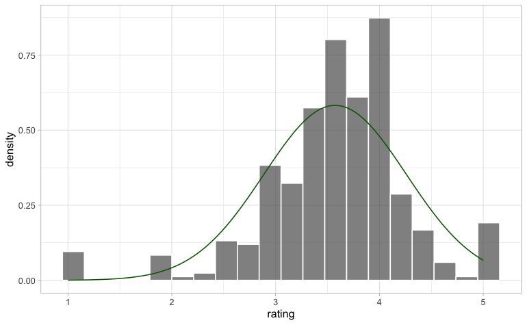

```r
samsung_mobile_phones %>%
  ggplot(aes(x = rating)) +
  geom_histogram(aes(y = ..density..), col = "white", bins = 20, alpha = 0.7) +
  theme_light() +
  stat_function(
    fun = dnorm,
    args = list(
      mean = samsung_stats$mean,
      sd = samsung_stats$sd
    ),
    col = "dark green"
  )
```

```r
NA
NA
```

The graph above confirms a slight left skew, which suggests that Samsung phones are rated highly as the most frequently occurring rating was close to 4 out of 5.

# Step 4

We can be more quantitative in comparing the distribution of top brand ratings with a normal distribution. You calculated the mean() and sd() of your distribution in an earlier question. Use these values to calculate the proportions of ratings within one-, two- and three standard deviations of the mean. Compare these proportions with those you expect for a normal distribution.

```r
samsung_mobile_phones %>%
  filter(rating >= samsung_stats$mean - samsung_stats$sd) %>%
  filter(rating <= samsung_stats$mean + samsung_stats$sd) %>%

  summarise(prop_within_1sd = n() / nrow(samsung_mobile_phones))
```

| prop_within_1sd |
| --- |
| 0.7934509 |

```r
NA
```

```r
samsung_mobile_phones %>%
  filter(rating >= samsung_stats$mean - (samsung_stats$sd*2)) %>%
  filter(rating <= samsung_stats$mean + (samsung_stats$sd*2)) %>%
  summarise(prop_within_2sd = n() / nrow(samsung_mobile_phones))
```

| prop_within_2sd |
| --- |
| 0.9193955 |

```r
NA
```

```r
samsung_mobile_phones %>%
  filter(rating >= samsung_stats$mean - (samsung_stats$sd*3)) %>%
  filter(rating <= samsung_stats$mean + (samsung_stats$sd*3)) %>%
  summarise(prop_within_3sd = n() / nrow(samsung_mobile_phones))
```

| prop_within_3sd |
| --- |
| 0.9798489 |

```r
NA
```

RESULTS:

1 standard deviation from mean (68%) = 0.7934509 or 79% of ratings 2 standard deviation from mean (95%) = 0.9193955 or 92% of ratings 3 standard deviation from mean (99.7%) = 0.9798489 or 98% of ratings